# Gun Control in US

What factors explain support for gun control in the United States?

# Introduction:

The term “gun control” refer to set of regulations that make the gun possession, distribution of guns stricter, to limit guns misuse, in USA gun control is one of most controversial topics, many people in the favor of more gun control policy and the other in a favor of less strict gun policy, this research will investigate some of the factors that may have a direct impact on supporting for gun control in USA.

# Literature and theory:

There are many factors can be searched to know the motive for supporting gun control policy, however in this research the focus will be on only four factors:

## 1.Number of State Gun Laws and gun control

In his book “in defense of gun control”, (LaFollette, 2018) presented one argues that had been used by pro-gun advocates, they claim that if we introduce more laws in the favor of gun control, this will lead to, incensing the gun ownership and the violence will increase as well. This argue based on the historical fact that when the liquor prohibited in 1920, there was an increase in consumption of the liqueur when it became illegal and a wave of violence occur over the distribution when criminals try to satisfy this illegal demand. So, does the laws in the favor of gun control may lead to a negative impact?

## 2.political party affiliation and political view effect on the support of gun control

political party affiliation and political view had been one of the factors impacts to the gun control policy, (Celinska, 2007) found that there is a correlation between the political view and the gun ownership, other studies such as (Meins & Washington, 2019) include the political view as factor effect the support of gun control in their model. thus, in this research I will try to find if this correlation can be found using a different dataset and if this correlation can be an indication for causality in this case.

## 3.The demographics of gun ownership and gun control policy

The Demographics can be a good factor for supporting the gun control, A research made by (pew research center, 2017) shows that the gun ownership most common among men, whites, this research will look to the relationship between the demographics namely, race and gender, and supporting gun control policy. And if there a confounding factor to be consider.

## 4.Mass shooting and gun control policy

The definition of mass murderers MM can give us an idea on what mass shooting means, MM can be defined according to FBI the person who kill at least four in single location (Kristin Goss and Philip J. Cook, 2014), the studies show “an increase in these incidents over the last few decades and again over the last five to ten years” (Gabor, 2016), so is the increase of mass shooting can lead to support gun control policy? according to (Luca et al., 2016) Mass shootings account for a small fraction of gun deaths in the United States but have a significant impact on gun policy”. (Crews & IGI Global, 2019) suggested that some of the mass shooting can be consider as act of terrorism based on the motivation of the shooter, therefore we may as well see how a terrorist attack motivate the supporting for gun control policy.

# Data and methodology

The main dataset was The General Social Surveys, 1972-2016, however the survey shows only the data from 2006 and the response for only 7 questions, also the dataset contains a lot of missing values. Therefore, this dataset will not be sufficient to investigate the different factors mentioned in Literature and theory section. therefore, I will be using different sources as well for each factor.

## number of State Gun Laws factor

There are two datasets are used, the (state firearm laws) data which contain the number of laws for each state since 1991, also the data form (RAND State-Level Firearm Ownership Database) which contain the HFR (Factor scores for household firearm ownership latent factor) by state and by year. The HFR can be used as an indication on how the number of laws per state can affect the gun ownership and gun control policy. A combined dataset will be used for this purpose.

## political party affiliation and political view factor

another two datasets had been used, one dataset form Kaggle named ” Gun Control Survey ” which contain 561record for different people, with their party affiliation and their opinion on some gun control policy, the second dataset is a survey conducted by PEW named (Sept18 public) which contain the point of view of 1,754 adults in USA on gun control policy. by plotting graphs for people opinions and their party affiliation we can get an idea on how the political party affiliation and political view my effect the supporting of gun control policy.

## demographics factor

another survey from PEW named (ATP W25) contain the demographics for 5,177 members of the ATP “The American Trends Panel” and their opinion on different political issues, one of them is the gun control policy. by preprocessing the dataset to simpler table that is contain the different demographics against their political point of view we may find how the demographics can affect the support for gun control policy.

## mass shooting factor

The data from The General Social Surveys as well as the Stanford Mass Shootings in America dataset that is have the information for the mass shooting in USA in last 50 year. we can investigate how the mass shooting is a factor affect gun control policy.

Some of the dataset had been prepressed using Excel and the other by R programming language.

# Results

## Number of State Gun Laws and gun control

Figure 1 shows that there are a strong negative correlation between the HFR (Factor scores for household firearm ownership latent factor) and total number of laws in state , which indicate that more gun control laws will not lead to an increasing gun’s ownership , this can confirm the claim by (LaFollette, 2018) when he argue that unlike the liquor Prohibited in 1920, the gun control laws is not aiming to ban the gun ownership but it will ensure that the guns will not be misused, Therefore , introducing more laws in the favor of gun control policy will not have a negative impact on the society.

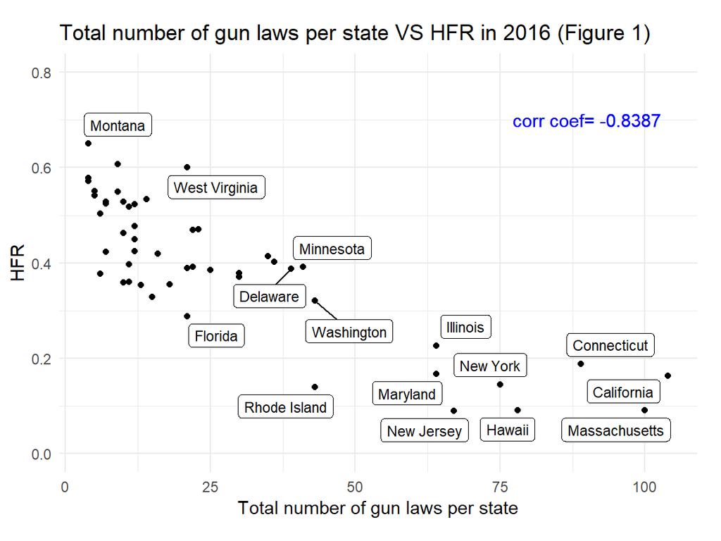

Moreover, Figure 2 shows relationship between the number of gun laws for the top four populated states by year and the HRF, the negative correlation still present, we can infer that the raise of state Gun Laws may lead the public opinion toward supporting gun control policy or at least minimize the gun ownership trend.

```
## [1] "The correlation between HFR and the number of gun laws since 1991 in california -0.947"
```

```
## [1] "The correlation between HFR and the number of gun laws since 1991 in florida -0.674"
```

```
## [1] "The correlation between HFR and the number of gun laws since 1991 in newyork  -0.906"
```

```
## [1] "The correlation between HFR and the number of gun laws since 1991in texas  -0.896"
```

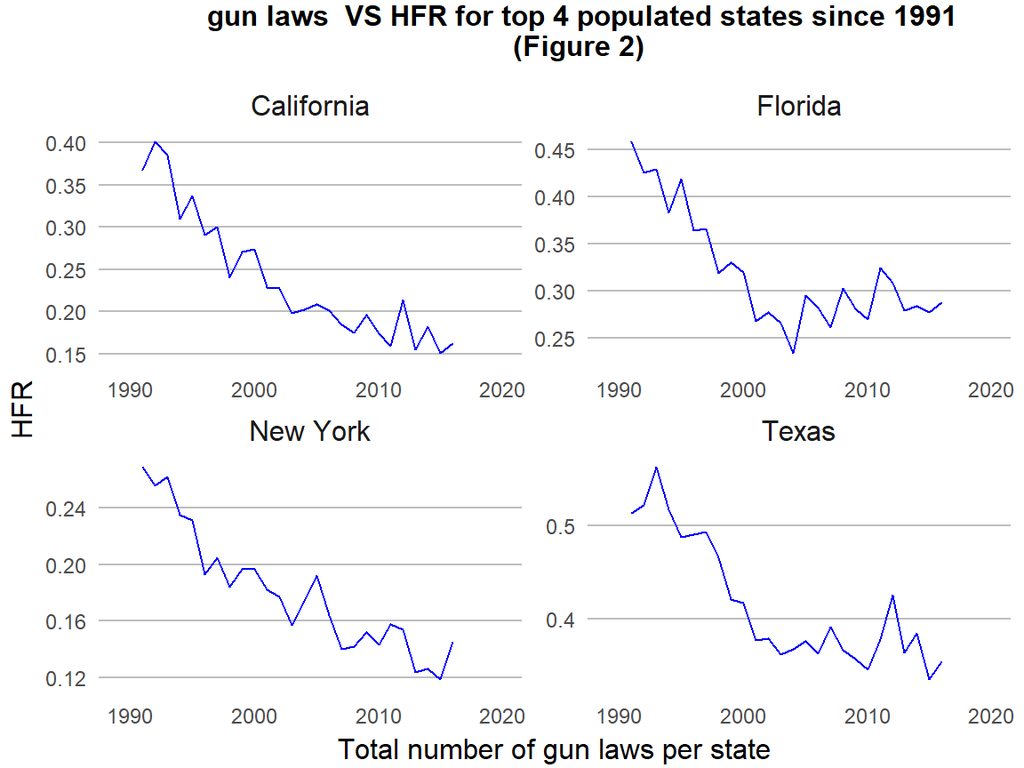

## political party affiliation and political view factor

By using “Gun Control Survey” the Figure 3-5 were generated, which shows that unbalance number of observations for each party, and it also shows both party member in the survey lean to more strict gun control policy, however the ratio between the people in favor of gun control in democratic party compare to the people against gun control in democratic party higher than the republican party. this result was unusual.

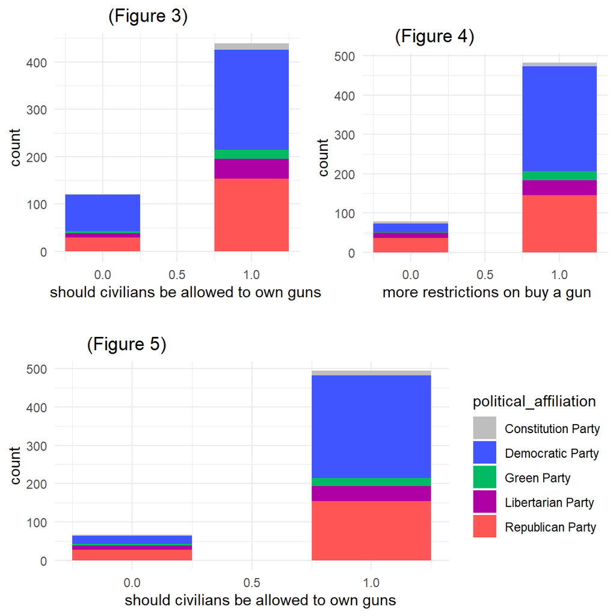

And the result form PEW (Sept18 public) shows more regular result in figure 6 with the majority of democratic in favors of gun control and majority of republican in the opposite of gun control. This result confirms the correlation between political party affiliation and gun control that was found by (Celinska, 2007) but it cannot confirm the causality.

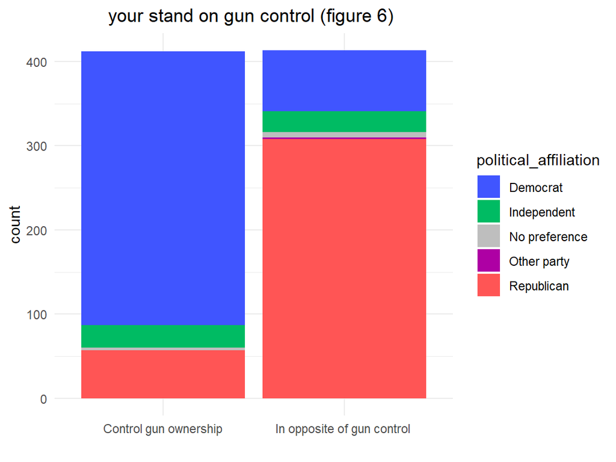

## The demographics factor

The figure 7 generated by (ATP W25) data is not showing a significant different between the gender for supporting or opposite gun control policy, nevertheless, the research made by (pew research center, 2017) based on a survey from April 2017, shows that gun ownership most common among men with almost 39% men personally on gun compare to 22% women.

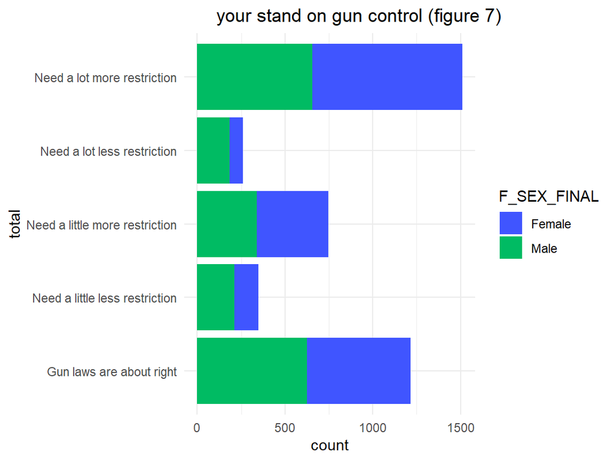

On the other hand, the following table shows that most black people in a favor of more restriction with 72% followed by 60% for Hispanic, 56% for other races and 52% of white people.

[interactive chart not shown]